# **Data Science con `R`**

## Melanoma maligno en los Estados Unidos

Fisher y Belle (1993) reportan tasas de mortalidad por melanoma maligno de la piel en hombres blancos durante el período 1950-1969, en cada estado del territorio continental de los Estados Unidos.

```r
data("USmelanoma",package="HSAUR2")
```

- `mortality` número de varones blancos muertos por melanoma maligno entre 1950 y 1969 por cada millón de habitantes.
- `latitude`: latitud del centro geográfico del estado.
- `longitude`: longitud del centro geográfico de cada estado.
- `ocean`: variable binaria que indica la contigüidad a un océano a niveles ‘no’ o ‘sí’.

**Gráficos de las tasas de mortalidad**

```r
xr <- range(USmelanoma$mortality) * c(0.9, 1.1)
```

Boxplot

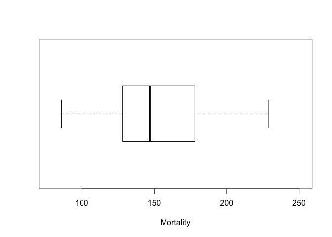

```r
#layout(matrix(1:2, nrow = 2))
boxplot(USmelanoma$mortality, ylim = xr, horizontal = TRUE,xlab = "Mortality")
```

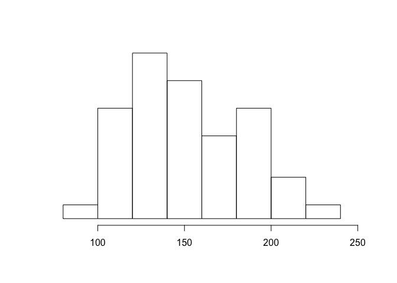

```r
hist(USmelanoma$mortality, xlim = xr, xlab = "", main = "",axes = FALSE, ylab = "")
axis(1)
```

Tasas de mortalidad por melanoma maligno por contigüidad a un océano

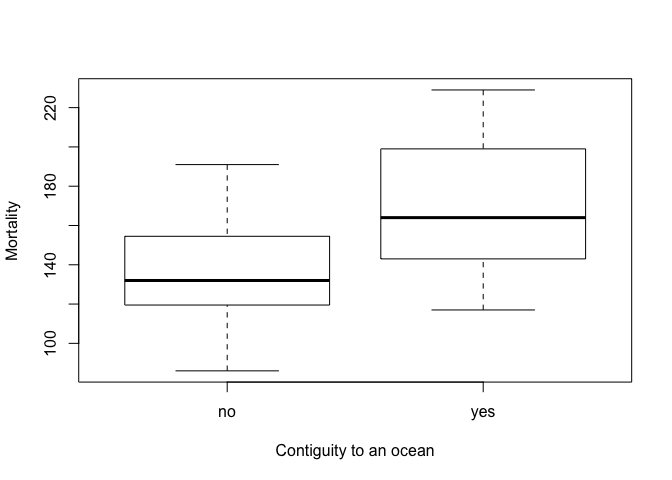

```r
plot(mortality ~ ocean, data = USmelanoma, xlab = "Contiguity to an ocean", ylab = "Mortality")
```

Los histogramas a menudo pueden ser engañosos a la hora de mostrar distribuciones debido a su dependencia del número de clases elegidas. Una alternativa es estimar formalmente la función de densidad de una variable y luego graficar la estimación resultante.

Las densidades estimadas de las tasas de mortalidad por melanoma maligno por contigüidad a un océano se ven así:

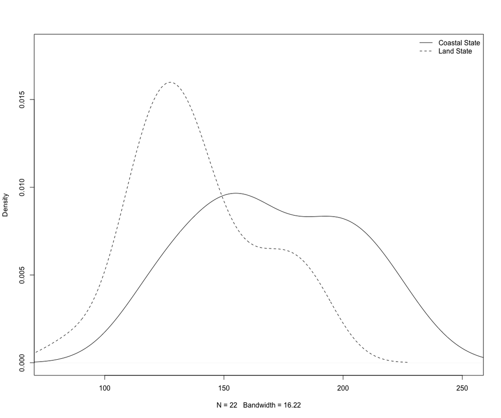

```r
dyes <- with(USmelanoma, density(mortality[ocean == "yes"]))
dno <- with(USmelanoma, density(mortality[ocean == "no"]))
plot(dyes, lty = 1, xlim = xr, main = "", ylim = c(0, 0.018))
lines(dno, lty = 2)
legend("topright", lty = 1:2, legend = c("Coastal State","Land State"), bty = "n")
```

Ahora podríamos pasar a ver cómo se relacionan las tasas de mortalidad con la ubicación geográfica de un estado representada por la latitud y longitud del centro del estado.

[figure not shown]

```r
layout(matrix(1:2, ncol = 2))
plot(mortality ~ -longitude, data = USmelanoma)
plot(mortality ~ latitude, data = USmelanoma)
```

Los datos contienen la longitud y latitud de los centroides.

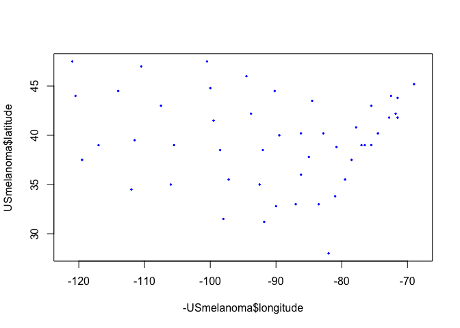

```r
plot(-USmelanoma$longitude,USmelanoma$latitude,asp=1.5,cex=.3,pch=19,col="blue")
```

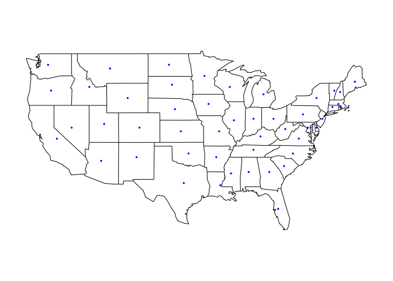

```r
library("sp")
library("maps")
library("maptools")
library("RColorBrewer")
map("state")
points(-USmelanoma$longitude,USmelanoma$latitude,asp=1.5,cex=.3,pch=19,col="blue")
```

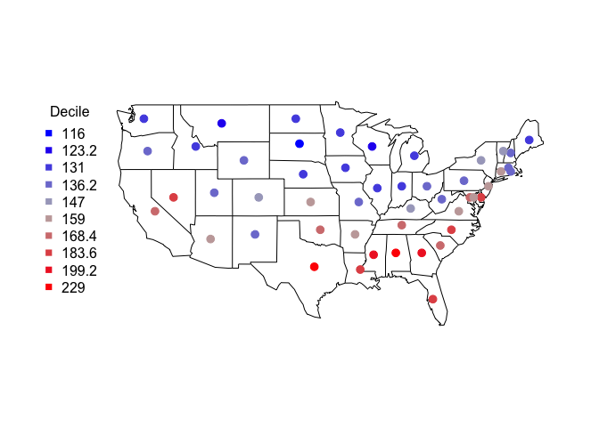

```r
# Crear una función para generar una paleta de colores continua
rbPal <- colorRampPalette(c('blue','grey','red'))
# Esto añade una columna de valores de color
# basado en los valores de y
USmelanoma$Col <- (rbPal(10)[as.numeric(cut(USmelanoma$mortality,breaks = 10))])
map("state",xlim=c(-135,-65))
points(-USmelanoma$longitude,USmelanoma$latitude,col=USmelanoma$Col,asp=1.5,pch=19,cex=1.2)
legend("topleft",title="Decile",legend=quantile(USmelanoma$mortality,seq(0.1,1,l=10)),col =rbPal(10),pch=15,cex=1.,box.col = NA)
```

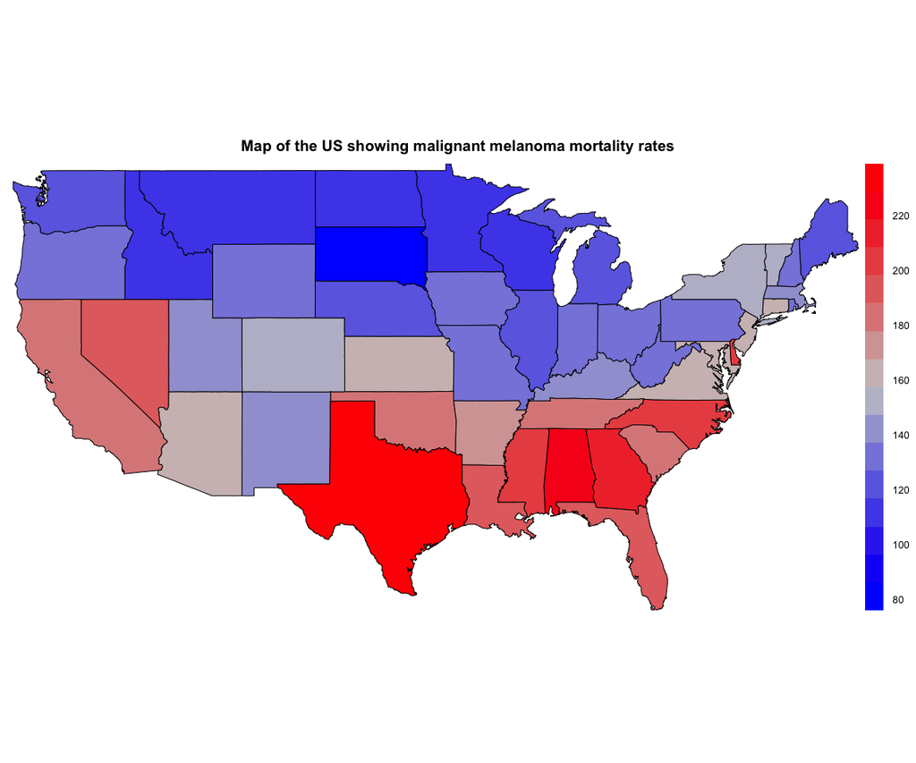

```r
states <- map("state", plot = FALSE, fill = TRUE)
IDs <- sapply(strsplit(states$names, ":"), function(x) x[1])
rownames(USmelanoma) <- tolower(rownames(USmelanoma))

us1 <- map2SpatialPolygons(states, IDs=IDs,proj4string = CRS("+proj=longlat +datum=WGS84"))
us2 <- SpatialPolygonsDataFrame(us1, USmelanoma)

col <- colorRampPalette(c('blue', 'gray80','red'))

spplot(us2, "mortality", col.regions = col(200),par.settings = list(axis.line = list(col =  'transparent')),main="Map of the US showing malignant melanoma mortality rates")
```

# Gráficos avanzados con la librería `ggplot2`

- Toma como referencia una metodología de visualización de datos llamada The Grammar of Graphics, (Wilkinson, 2005).
- La idea es describir los mapeos visuales para poder armar visualizaciones complejas sin preocuparnos por la parte dificil.
- Gramática consistente basada en grammar of graphics (Wilkinson, 2005)
- Librería muy flexible
- Mantenimiento muy activo de la librería
- Gran lista de distribución y con mucha participación
- Es posible crear gráficos visualmente atractivos y elegantes
- Simple gestión de leyendas

[Más información](http://rstudio-pubs-static.s3.amazonaws.com/2795_901030c4ef944c7797f39bcdac099d74.html)

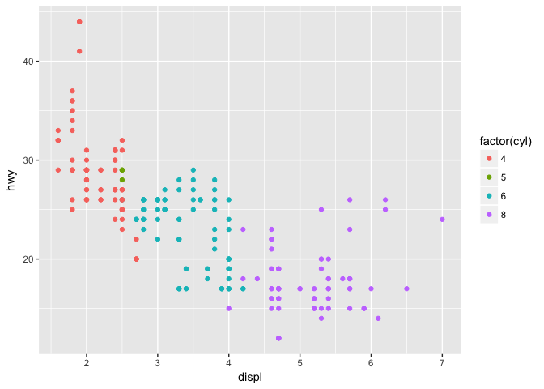

```r
library(ggplot2)
?qplot
qplot(displ, hwy, data = mpg, colour = factor(cyl))
```

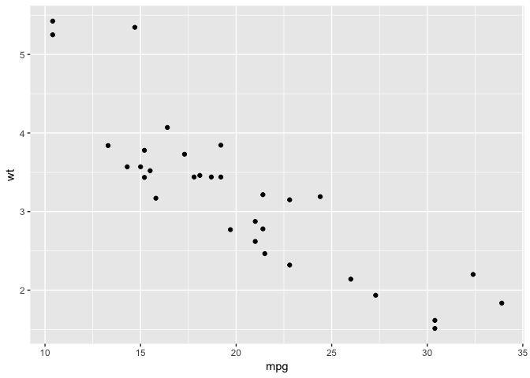

```r
qplot(mpg, wt, data = mtcars)
```

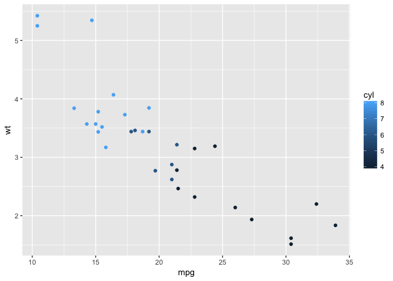

```r
qplot(mpg, wt, data = mtcars, colour = cyl)
```

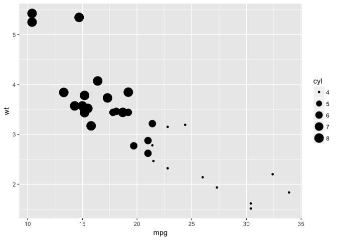

```r
qplot(mpg, wt, data = mtcars, size = cyl)
```

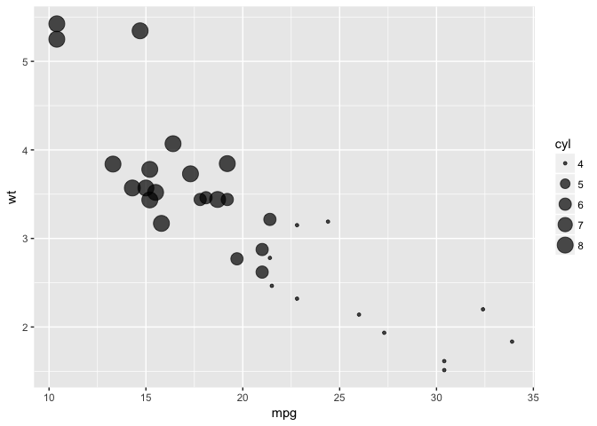

```r
qplot(mpg, wt, data = mtcars, size = cyl, alpha = I(0.7))
```

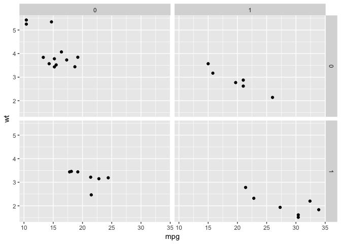

```r
qplot(mpg, wt, data = mtcars, facets = vs ~ am)
```

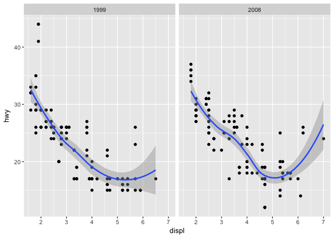

```r
qplot(displ, hwy, data=mpg, facets = . ~ year) + geom_smooth()
```

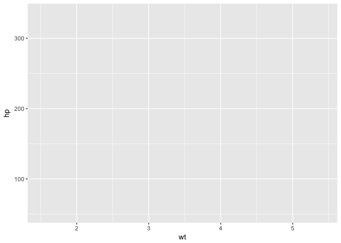

```r
p <- ggplot(mtcars)
p <- p + aes(wt, hp)
p
```

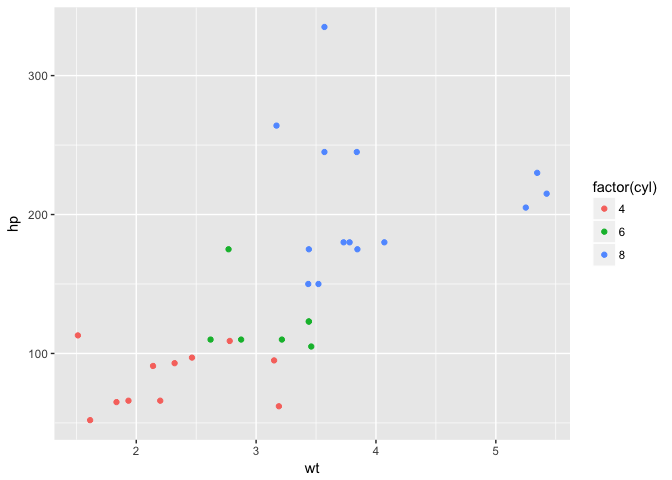

```r
p + geom_point(aes(colour = factor(cyl)))
```

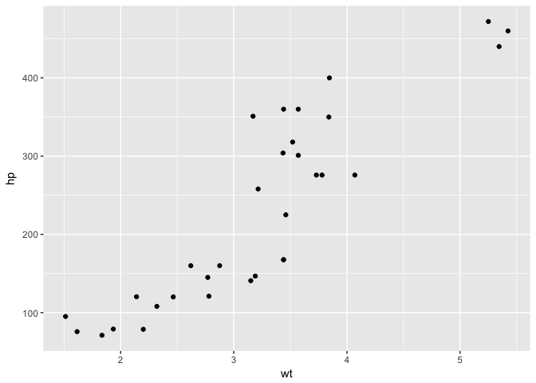

```r
p + geom_point(aes(y = disp))
```

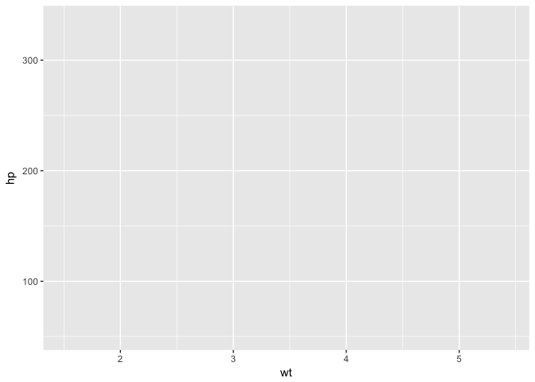

```r
p
```

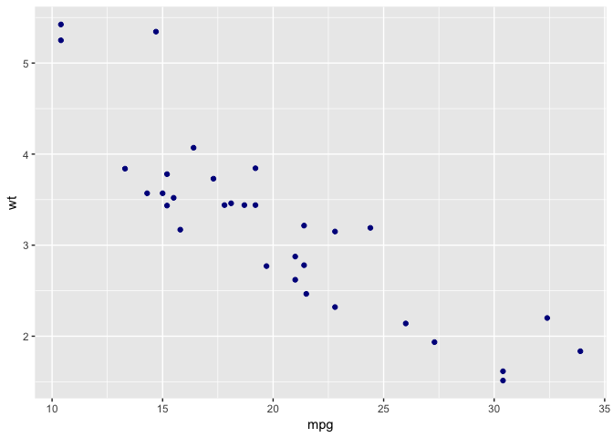

```r
p <- ggplot(mtcars, aes(mpg, wt))
p + geom_point(colour = "darkblue")
```

```r
filepath <- "http://idaejin.github.io/bcam-courses/azti-2016/introR/data/ggplot2_data.txt"

myData<-read.table(file=url(filepath),header=TRUE,sep="\t")

str(myData)
```

```
## 'data.frame':    218 obs. of  4 variables:
##  $ Tribe: Factor w/ 8 levels "Aepycerotini",..: 1 1 1 1 1 1 1 1 1 1 ...
##  $ Hab  : Factor w/ 4 levels "F","H","L","O": 3 3 3 3 3 3 3 3 3 3 ...
##  $ BM   : num  56.2 56.2 56.2 56.2 56.2 ...
##  $ var1 : num  36.5 40.9 37 36.2 36.6 37.7 37.3 39 37.7 35.3 ...
```

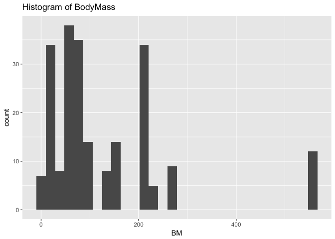

```r
qplot(data=myData,x=BM,main="Histogram of BodyMass")
```

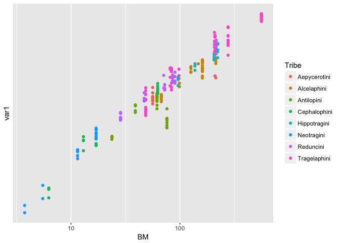

```r
qplot(data=myData,x=BM,y=var1,log="xy",color=Tribe)
```

## Maps

Paquetes para Regresión Espacial / Geoestadística / Métodos de Patrones de Puntos Espaciales

- `sp`, `maptools`, `spatstat`
- `maps`

```r
library(maps)
```

Sintaxis básica

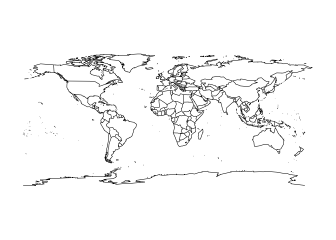

```r
map(database = "world",regions=".")
```

Hay bases de datos disponibles para EE.UU., Francia, Italia y Nueva Zelanda. Para otros países, es necesario importar una base de datos con el mapa correspondiente.

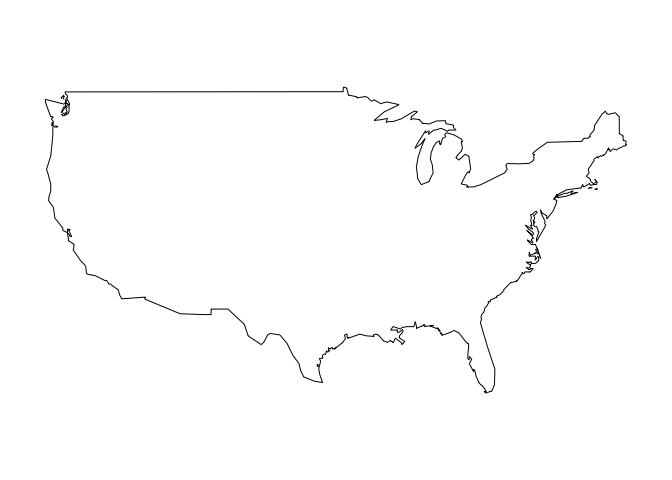

```r
map(database = "usa")
```

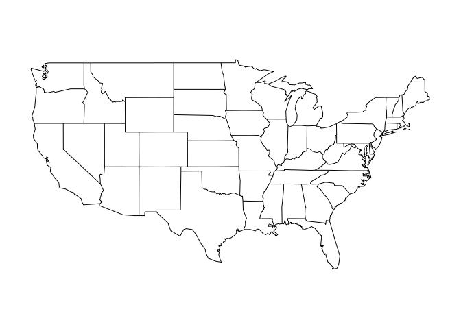

```r
map("state")
```

Con el paquete `RgoogleMaps`, puedes dibujar un fondo desde Google Maps!

[figure not shown]

```r
library(RgoogleMaps)
lat <- -33.447487
lon <- -70.673676
center <- c(lat, lon)
zoom <- 18
MyMap <- GetMap(center=center, zoom=zoom)
PlotOnStaticMap(MyMap)
text(lat,lon, "X")
```

`ggmap` ofrece capacidades gráficas como `ggplot2``.

```r
library(ggmap)
geocode("Alameda, Santiago de Chile, Chile")
qmap("Santiago, Chile", zoom = 14)
mapdist("Valparaíso", "Santiago")
route("Valparaíso, Chile", "Santiago, Chile", alternatives = FALSE)
```

**Ejemplo de uso de `qmap` y `ggplot2`**

```r
desde <- 'Valparaíso, Chile'
hasta <- 'Santiago, Chile'

rutas <- route(desde, hasta, alternatives = FALSE)
head(rutas)

ggplot() +
  geom_segment(aes(x = startLon, y = startLat, xend = endLon, yend = endLat, colour = route), size = 1.5, data = rutas)
```